# Insurance Veri Madenciliği Projesi

Doruk Kopdağ

2026-05-11

# Gerekli Paketler

```r
library(tidyverse)
library(broom)
library(pROC)
```

# Veri Setinin Yüklenmesi

```r
veri <- read.csv("insurance.csv")
df <- veri
```

# Veri Seti Hakkında Bilgi

Bu projede kullanılan veri seti **insurance** veri setidir. Veri madenciliği kapsamında bireylerin yaş, cinsiyet, BMI, çocuk sayısı, sigara kullanımı, bölge ve sigorta maliyeti değişkenleri incelenmiştir.

```r
head(df)
```

```
##   age    sex    bmi children smoker    region   charges
## 1  19 female 27.900        0    yes southwest 16884.924
## 2  18   male 33.770        1     no southeast  1725.552
## 3  28   male 33.000        3     no southeast  4449.462
## 4  33   male 22.705        0     no northwest 21984.471
## 5  32   male 28.880        0     no northwest  3866.855
## 6  31 female 25.740        0     no southeast  3756.622
```

```r
dim(df)
```

```
## [1] 1338    7
```

```r
str(df)
```

```
## 'data.frame':    1338 obs. of  7 variables:
##  $ age     : int  19 18 28 33 32 31 46 37 37 60 ...
##  $ sex     : chr  "female" "male" "male" "male" ...
##  $ bmi     : num  27.9 33.8 33 22.7 28.9 ...
##  $ children: int  0 1 3 0 0 0 1 3 2 0 ...
##  $ smoker  : chr  "yes" "no" "no" "no" ...
##  $ region  : chr  "southwest" "southeast" "southeast" "northwest" ...
##  $ charges : num  16885 1726 4449 21984 3867 ...
```

```r
summary(df)
```

```
##       age            sex                 bmi           children
##  Min.   :18.00   Length:1338        Min.   :15.96   Min.   :0.000
##  1st Qu.:27.00   Class :character   1st Qu.:26.30   1st Qu.:0.000
##  Median :39.00   Mode  :character   Median :30.40   Median :1.000
##  Mean   :39.21                      Mean   :30.66   Mean   :1.095
##  3rd Qu.:51.00                      3rd Qu.:34.69   3rd Qu.:2.000
##  Max.   :64.00                      Max.   :53.13   Max.   :5.000
##     smoker             region             charges
##  Length:1338        Length:1338        Min.   : 1122
##  Class :character   Class :character   1st Qu.: 4740
##  Mode  :character   Mode  :character   Median : 9382
##                                        Mean   :13270
##                                        3rd Qu.:16640
##                                        Max.   :63770
```

# Değişken Açıklamaları

| Değişken | Tür | Açıklama |
| --- | --- | --- |
| age | Sayısal | Yaş |
| sex | Kategorik | Cinsiyet |
| bmi | Sayısal | Vücut kitle indeksi |
| children | Sayısal | Çocuk sayısı |
| smoker | Kategorik | Sigara kullanımı |
| region | Kategorik | Bölge |
| charges | Sayısal | Sigorta maliyeti |

# Frekans Analizi

```r
table(df$sex)
```

```
##
## female   male
##    662    676
```

```r
table(df$smoker)
```

```
##
##   no  yes
## 1064  274
```

```r
table(df$region)
```

```
##
## northeast northwest southeast southwest
##       324       325       364       325
```

Bu bölümde kategorik değişkenlerin dağılımları incelenmiştir.

# Korelasyon Analizi

```r
cor(df$age, df$charges)
```

```
## [1] 0.2990082
```

```r
cor(df$bmi, df$charges)
```

```
## [1] 0.198341
```

```r
cor(df$children, df$charges)
```

```
## [1] 0.06799823
```

## Korelasyon Yorumu

Korelasyon katsayısı -1 ile +1 arasında değer almaktadır.

- +1’e yakın değer güçlü pozitif ilişkiyi gösterir.
- -1’e yakın değer güçlü negatif ilişkiyi gösterir.
- 0’a yakın değer zayıf ilişkiyi gösterir.

Bu projede korelasyon analizi ile yaş, BMI ve çocuk sayısı değişkenlerinin sigorta maliyeti ile ilişkisi incelenmiştir.

# Nihai Veri Seti Oluşturma: 8 Aşama

## 1. Veri Toplama

Insurance veri seti projeye aktarılmıştır. Veri setinde bireylerin demografik ve sağlıkla ilişkili bilgileri yer almaktadır.

## 2. Veri Setini İnceleme

```r
names(df)
```

```
## [1] "age"      "sex"      "bmi"      "children" "smoker"   "region"   "charges"
```

```r
dim(df)
```

```
## [1] 1338    7
```

```r
head(df)
```

```
##   age    sex    bmi children smoker    region   charges
## 1  19 female 27.900        0    yes southwest 16884.924
## 2  18   male 33.770        1     no southeast  1725.552
## 3  28   male 33.000        3     no southeast  4449.462
## 4  33   male 22.705        0     no northwest 21984.471
## 5  32   male 28.880        0     no northwest  3866.855
## 6  31 female 25.740        0     no southeast  3756.622
```

Veri setindeki satır ve sütun sayısı incelenmiş, değişken isimleri kontrol edilmiştir.

## 3. Eksik Veri Kontrolü

```r
colSums(is.na(df))
```

```
##      age      sex      bmi children   smoker   region  charges
##        0        0        0        0        0        0        0
```

Eksik veri kontrolü yapılarak analiz öncesinde veri setinde boş değer olup olmadığı incelenmiştir.

## 4. Aykırı Değer Kontrolü

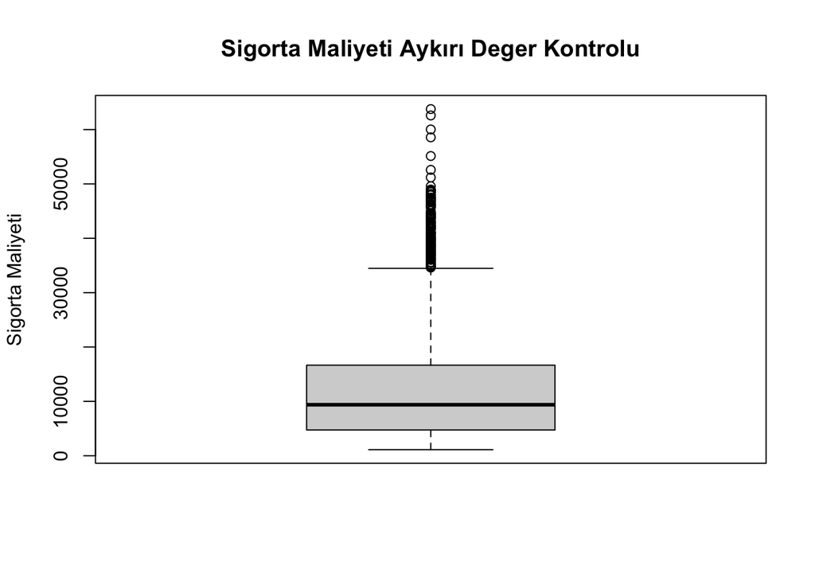

```r
boxplot(df$charges,
        main = "Sigorta Maliyeti Aykırı Deger Kontrolu",
        ylab = "Sigorta Maliyeti")
```

Boxplot grafiği ile sigorta maliyeti değişkeninde aykırı değer olup olmadığı görsel olarak incelenmiştir.

## 5. Veri Dönüştürme

```r
df$sex <- as.factor(df$sex)
df$smoker <- as.factor(df$smoker)
df$region <- as.factor(df$region)

str(df)
```

```
## 'data.frame':    1338 obs. of  7 variables:
##  $ age     : int  19 18 28 33 32 31 46 37 37 60 ...
##  $ sex     : Factor w/ 2 levels "female","male": 1 2 2 2 2 1 1 1 2 1 ...
##  $ bmi     : num  27.9 33.8 33 22.7 28.9 ...
##  $ children: int  0 1 3 0 0 0 1 3 2 0 ...
##  $ smoker  : Factor w/ 2 levels "no","yes": 2 1 1 1 1 1 1 1 1 1 ...
##  $ region  : Factor w/ 4 levels "northeast","northwest",..: 4 3 3 2 2 3 3 2 1 2 ...
##  $ charges : num  16885 1726 4449 21984 3867 ...
```

Kategorik değişkenler faktör veri tipine dönüştürülmüştür.

## 6. Kodlama İşlemi

```r
df$smoker_binary <- ifelse(df$smoker == "yes", 1, 0)

table(df$smoker, df$smoker_binary)
```

```
##
##          0    1
##   no  1064    0
##   yes    0  274
```

Lojistik regresyon için sigara kullanımı değişkeni 0-1 formatına dönüştürülmüştür.

- 1 = Sigara içiyor
- 0 = Sigara içmiyor

## 7. Özellik Seçimi

```r
secili_degiskenler <- c("age", "bmi", "children", "smoker_binary", "charges")
secili_degiskenler
```

```
## [1] "age"           "bmi"           "children"      "smoker_binary"
## [5] "charges"
```

Regresyon ve lojistik regresyon analizleri için kullanılacak değişkenler belirlenmiştir.

## 8. Nihai Veri Seti Oluşturma

```r
nihai_veri <- df[, c("age", "bmi", "children", "smoker_binary", "charges")]
head(nihai_veri)
```

```
##   age    bmi children smoker_binary   charges
## 1  19 27.900        0             1 16884.924
## 2  18 33.770        1             0  1725.552
## 3  28 33.000        3             0  4449.462
## 4  33 22.705        0             0 21984.471
## 5  32 28.880        0             0  3866.855
## 6  31 25.740        0             0  3756.622
```

```r
summary(nihai_veri)
```

```
##       age             bmi           children     smoker_binary
##  Min.   :18.00   Min.   :15.96   Min.   :0.000   Min.   :0.0000
##  1st Qu.:27.00   1st Qu.:26.30   1st Qu.:0.000   1st Qu.:0.0000
##  Median :39.00   Median :30.40   Median :1.000   Median :0.0000
##  Mean   :39.21   Mean   :30.66   Mean   :1.095   Mean   :0.2048
##  3rd Qu.:51.00   3rd Qu.:34.69   3rd Qu.:2.000   3rd Qu.:0.0000
##  Max.   :64.00   Max.   :53.13   Max.   :5.000   Max.   :1.0000
##     charges
##  Min.   : 1122
##  1st Qu.: 4740
##  Median : 9382
##  Mean   :13270
##  3rd Qu.:16640
##  Max.   :63770
```

Bu aşamada analizde kullanılacak nihai veri seti oluşturulmuştur.

# Basit Doğrusal Regresyon

```r
lm1 <- lm(charges ~ age, data = df)
summary(lm1)
```

```
##
## Call:
## lm(formula = charges ~ age, data = df)
##
## Residuals:
##    Min     1Q Median     3Q    Max
##  -8059  -6671  -5939   5440  47829
##
## Coefficients:
##             Estimate Std. Error t value Pr(>|t|)
## (Intercept)   3165.9      937.1   3.378 0.000751 ***
## age            257.7       22.5  11.453  < 2e-16 ***
## ---
## Signif. codes:  0 '***' 0.001 '**' 0.01 '*' 0.05 '.' 0.1 ' ' 1
##
## Residual standard error: 11560 on 1336 degrees of freedom
## Multiple R-squared:  0.08941,    Adjusted R-squared:  0.08872
## F-statistic: 131.2 on 1 and 1336 DF,  p-value: < 2.2e-16
```

## Model Yorumu

Bu modelde yaş değişkeninin sigorta maliyeti üzerindeki etkisi incelenmiştir. Yaş arttıkça sigorta maliyetinin de artma eğiliminde olduğu gözlemlenmektedir.

# Çoklu Doğrusal Regresyon

```r
options(scipen=999)
model1 <- lm(charges ~ age + bmi + children, data = df)
model2 <- lm(charges ~ age + bmi + smoker_binary, data = df)
model3 <- lm(charges ~ age + sex + bmi + children + smoker + region, data = df)

summary(model1)
```

```
##
## Call:
## lm(formula = charges ~ age + bmi + children, data = df)
##
## Residuals:
##    Min     1Q Median     3Q    Max
## -13884  -6994  -5092   7125  48627
##
## Coefficients:
##             Estimate Std. Error t value             Pr(>|t|)
## (Intercept) -6916.24    1757.48  -3.935       0.000087368124 ***
## age           239.99      22.29  10.767 < 0.0000000000000002 ***
## bmi           332.08      51.31   6.472       0.000000000135 ***
## children      542.86     258.24   2.102               0.0357 *
## ---
## Signif. codes:  0 '***' 0.001 '**' 0.01 '*' 0.05 '.' 0.1 ' ' 1
##
## Residual standard error: 11370 on 1334 degrees of freedom
## Multiple R-squared:  0.1201, Adjusted R-squared:  0.1181
## F-statistic: 60.69 on 3 and 1334 DF,  p-value: < 0.00000000000000022
```

```r
summary(model2)
```

```
##
## Call:
## lm(formula = charges ~ age + bmi + smoker_binary, data = df)
##
## Residuals:
##      Min       1Q   Median       3Q      Max
## -12415.4  -2970.9   -980.5   1480.0  28971.8
##
## Coefficients:
##                Estimate Std. Error t value            Pr(>|t|)
## (Intercept)   -11676.83     937.57  -12.45 <0.0000000000000002 ***
## age              259.55      11.93   21.75 <0.0000000000000002 ***
## bmi              322.62      27.49   11.74 <0.0000000000000002 ***
## smoker_binary  23823.68     412.87   57.70 <0.0000000000000002 ***
## ---
## Signif. codes:  0 '***' 0.001 '**' 0.01 '*' 0.05 '.' 0.1 ' ' 1
##
## Residual standard error: 6092 on 1334 degrees of freedom
## Multiple R-squared:  0.7475, Adjusted R-squared:  0.7469
## F-statistic:  1316 on 3 and 1334 DF,  p-value: < 0.00000000000000022
```

```r
summary(model3)
```

```
##
## Call:
## lm(formula = charges ~ age + sex + bmi + children + smoker +
##     region, data = df)
##
## Residuals:
##      Min       1Q   Median       3Q      Max
## -11304.9  -2848.1   -982.1   1393.9  29992.8
##
## Coefficients:
##                 Estimate Std. Error t value             Pr(>|t|)
## (Intercept)     -11938.5      987.8 -12.086 < 0.0000000000000002 ***
## age                256.9       11.9  21.587 < 0.0000000000000002 ***
## sexmale           -131.3      332.9  -0.394             0.693348
## bmi                339.2       28.6  11.860 < 0.0000000000000002 ***
## children           475.5      137.8   3.451             0.000577 ***
## smokeryes        23848.5      413.1  57.723 < 0.0000000000000002 ***
## regionnorthwest   -353.0      476.3  -0.741             0.458769
## regionsoutheast  -1035.0      478.7  -2.162             0.030782 *
## regionsouthwest   -960.0      477.9  -2.009             0.044765 *
## ---
## Signif. codes:  0 '***' 0.001 '**' 0.01 '*' 0.05 '.' 0.1 ' ' 1
##
## Residual standard error: 6062 on 1329 degrees of freedom
## Multiple R-squared:  0.7509, Adjusted R-squared:  0.7494
## F-statistic: 500.8 on 8 and 1329 DF,  p-value: < 0.00000000000000022
```

# Model Karşılaştırmaları

```r
compare_models <- function(model, actual) {
  preds <- predict(model)
  rmse <- sqrt(mean((actual - preds)^2))
  mae <- mean(abs(actual - preds))
  r2 <- summary(model)$r.squared
  return(c(RMSE = rmse, MAE = mae, R2 = r2))
}

results <- rbind(
  Model_1 = compare_models(model1, df$charges),
  Model_2 = compare_models(model2, df$charges),
  Model_3 = compare_models(model3, df$charges)
)

round(results, 3)
```

```
##              RMSE      MAE    R2
## Model_1 11355.318 9015.442 0.120
## Model_2  6083.206 4216.776 0.747
## Model_3  6041.680 4170.887 0.751
```

## Seçilen Model: Model 3

Model 3, diğer modellere göre daha fazla değişken içerdiği için sigorta maliyetini açıklamada daha kapsamlıdır. Bu nedenle tahmin aşamasında **Model 3** seçilmiştir.

# Regresyon İçin Tahmin

```r
yeni_kisi_regresyon <- data.frame(
  age = 40,
  sex = factor("male", levels = levels(df$sex)),
  bmi = 28,
  children = 2,
  smoker = factor("yes", levels = levels(df$smoker)),
  region = factor("southeast", levels = levels(df$region))
)

regresyon_tahmini <- predict(model3, newdata = yeni_kisi_regresyon)
regresyon_tahmini
```

```
##        1
## 31466.33
```

## Regresyon Tahmin Yorumu

Oluşturulan bağımsız yeni kişi için Model 3 kullanılarak tahmini sigorta maliyeti hesaplanmıştır. Tahmin sonucu, kişinin yaş, cinsiyet, BMI, çocuk sayısı, sigara kullanımı ve bölge bilgilerine göre beklenen sigorta maliyetini göstermektedir.

# Katsayı Yorumları

## age

Yaş arttıkça sigorta maliyeti artma eğilimindedir.

## bmi

BMI değeri arttıkça sağlık riskleri artabileceği için sigorta maliyeti yükselebilir.

## smoker

Sigara kullanan bireylerin sigorta maliyetleri daha yüksek olabilir.

## children

Çocuk sayısı sigorta maliyetini etkileyebilmektedir.

# Lojistik Regresyon: Sigara İçen / İçmeyen Analizi

Bu bölümde lojistik regresyon analizi ile bireyin sigara içip içmediği tahmin edilmiştir. Bağımlı değişken **smoker_binary** değişkenidir.

- 1 = Sigara içiyor
- 0 = Sigara içmiyor

```r
lojistik_model <- glm(smoker_binary ~ age + bmi + children + charges,
                      data = df,
                      family = binomial)

summary(lojistik_model)
```

```
##
## Call:
## glm(formula = smoker_binary ~ age + bmi + children + charges,
##     family = binomial, data = df)
##
## Coefficients:
##                Estimate  Std. Error z value             Pr(>|z|)
## (Intercept)  5.61406029  1.05272320   5.333 0.000000096660211624 ***
## age         -0.09978012  0.01314391  -7.591 0.000000000000031657 ***
## bmi         -0.35236777  0.04373411  -8.057 0.000000000000000782 ***
## children    -0.23375549  0.12721455  -1.837               0.0661 .
## charges      0.00038809  0.00003004  12.920 < 0.0000000000000002 ***
## ---
## Signif. codes:  0 '***' 0.001 '**' 0.01 '*' 0.05 '.' 0.1 ' ' 1
##
## (Dispersion parameter for binomial family taken to be 1)
##
##     Null deviance: 1356.63  on 1337  degrees of freedom
## Residual deviance:  308.54  on 1333  degrees of freedom
## AIC: 318.54
##
## Number of Fisher Scoring iterations: 8
```

## Lojistik Regresyon Yorumu

Bu modelde bireyin yaş, BMI, çocuk sayısı ve sigorta maliyeti bilgilerine göre sigara içme olasılığı tahmin edilmektedir. Lojistik regresyon sonucu 0 ile 1 arasında bir olasılık üretir.

- Olasılık 0.50 ve üzerindeyse birey **sigara içiyor** şeklinde sınıflandırılır.
- Olasılık 0.50’nin altındaysa birey **sigara içmiyor** şeklinde sınıflandırılır.

# Lojistik Regresyon İçin Tahmin

```r
yeni_kisi_lojistik <- data.frame(
  age = 40,
  bmi = 28,
  children = 2,
  charges = as.numeric(regresyon_tahmini)
)

sigara_olasiligi <- predict(lojistik_model,
                            newdata = yeni_kisi_lojistik,
                            type = "response")

sigara_sinifi <- ifelse(sigara_olasiligi >= 0.5,
                        "Sigara içiyor",
                        "Sigara içmiyor")

sigara_olasiligi
```

```
##        1
## 0.970712
```

```r
sigara_sinifi
```

```
##               1
## "Sigara içiyor"
```

## Lojistik Tahmin Yorumu

Yeni oluşturulan bağımsız kişi için sigara içme olasılığı hesaplanmıştır. Elde edilen olasılık 0.50 eşik değerine göre değerlendirilmiş ve birey **sigara içiyor / sigara içmiyor** şeklinde sınıflandırılmıştır.